# Tips

# Visualizing the Titanic Disaster

# Introduction:

# This exercise is based on the titanic Disaster dataset avaiable at Kaggle.

# To know more about the variables check here

# Step 1. Import the necessary libraries

```python
import pandas as pd
import matplotlib.pyplot as plt
import seaborn as sns
```

# Step 2. Import the dataset from this address

```python
url = 'https://raw.githubusercontent.com/guipsamora/pandas_exercises/master/07_Visualization/Titanic_Desaster/train.csv'
```

# Step 3. Assign it to a variable titanic

```python
titanic = pd.read_csv(url)
```

```python
titanic
```

|  | PassengerId | Survived | Pclass | Name | Sex | Age | SibSp | Parch | Ticket | Fare | Cabin | Embarked |
| --- | --- | --- | --- | --- | --- | --- | --- | --- | --- | --- | --- | --- |
| 0 | 1 | 0 | 3 | Braund, Mr. Owen Harris | male | 22.0 | 1 | 0 | A/5 21171 | 7.2500 | NaN | S |
| 1 | 2 | 1 | 1 | Cumings, Mrs. John Bradley (Florence Briggs Th... | female | 38.0 | 1 | 0 | PC 17599 | 71.2833 | C85 | C |
| 2 | 3 | 1 | 3 | Heikkinen, Miss. Laina | female | 26.0 | 0 | 0 | STON/O2. 3101282 | 7.9250 | NaN | S |
| 3 | 4 | 1 | 1 | Futrelle, Mrs. Jacques Heath (Lily May Peel) | female | 35.0 | 1 | 0 | 113803 | 53.1000 | C123 | S |
| 4 | 5 | 0 | 3 | Allen, Mr. William Henry | male | 35.0 | 0 | 0 | 373450 | 8.0500 | NaN | S |
| ... | ... | ... | ... | ... | ... | ... | ... | ... | ... | ... | ... | ... |
| 886 | 887 | 0 | 2 | Montvila, Rev. Juozas | male | 27.0 | 0 | 0 | 211536 | 13.0000 | NaN | S |
| 887 | 888 | 1 | 1 | Graham, Miss. Margaret Edith | female | 19.0 | 0 | 0 | 112053 | 30.0000 | B42 | S |
| 888 | 889 | 0 | 3 | Johnston, Miss. Catherine Helen "Carrie" | female | NaN | 1 | 2 | W./C. 6607 | 23.4500 | NaN | S |
| 889 | 890 | 1 | 1 | Behr, Mr. Karl Howell | male | 26.0 | 0 | 0 | 111369 | 30.0000 | C148 | C |
| 890 | 891 | 0 | 3 | Dooley, Mr. Patrick | male | 32.0 | 0 | 0 | 370376 | 7.7500 | NaN | Q |

891 rows × 12 columns

# Step 4. Set PassengerId as the index

```python
titanic.set_index('PassengerId', inplace= True)
```

# Step 5. Create a pie chart presenting the male/female proportion

```python
titanic['ismale'] = (titanic.Sex == 'male') * 1
```

```python
titanic['ismale']
```

```
PassengerId
1      1
2      0
3      0
4      0
5      1
      ..
887    1
888    0
889    0
890    1
891    1
Name: ismale, Length: 891, dtype: int32
```

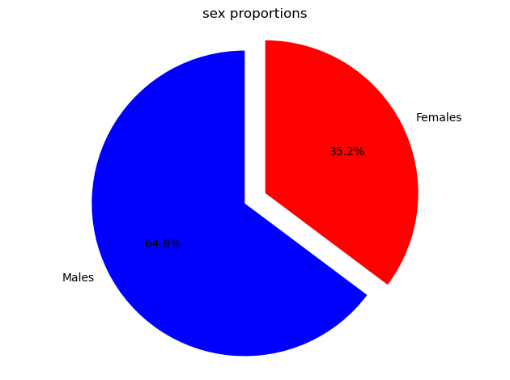

```python
males = (titanic['Sex'] == 'male').sum()
females =(titanic['Sex'] == 'female').sum()

proportions = [males , females]

plt.pie(proportions,

         labels = ['Males', 'Females'],

         shadow = False,

         colors = ['blue', 'red'],

         explode = (0.15 , 0),

         startangle = 90,

         autopct = '%1.1f%%',
        )
plt.axis('equal')

plt.title('sex proportions')
plt.tight_layout()
plt.show()
```

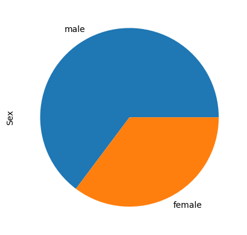

```python
titanic.Sex.value_counts().plot(kind='pie')
```

[figure not shown]

```python
titanic.ismale.plot(kind='pie')
```

# Step 6. Create a scatterplot with the Fare payed and the Age, differ the plot color by gender

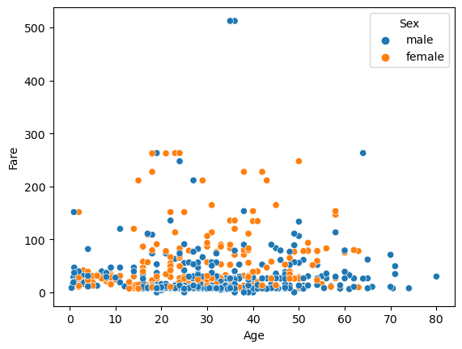

```python
sns.scatterplot(x = 'Age', y = 'Fare', hue='Sex', data=titanic )
```

# Step 7. How many people survived?

```python
titanic.Survived.sum()
```

```
342
```

# Step 8. Create a histogram with the Fare payed

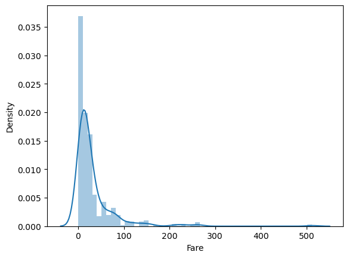

```python
sns.distplot(titanic.Fare)
```

# Pokemon

# Introduction:

# This time you will create the data.

# Step 1. Import the necessary libraries

```python
import pandas as pd
import numpy as np
```

# Step 2. Create a data dictionary that looks like the DataFrame below

```python
raw_data = {"evolution": ['Ivysaur','Charmeleon','Wartortle','Metapod'],
            "hp": [45, 39, 44, 45],
            "name": ['Bulbasaur', 'Charmander','Squirtle','Caterpie'],
            "pokedex": ['yes', 'no','yes','no'],
             "type": ['grass', 'fire', 'water', 'bug']
            }
```

# Step 3. Assign it to a variable called pokemon

```python
pokemon = pd.DataFrame(raw_data)
pokemon
```

|  | evolution | hp | name | pokedex | type |
| --- | --- | --- | --- | --- | --- |
| 0 | Ivysaur | 45 | Bulbasaur | yes | grass |
| 1 | Charmeleon | 39 | Charmander | no | fire |
| 2 | Wartortle | 44 | Squirtle | yes | water |
| 3 | Metapod | 45 | Caterpie | no | bug |

# Step 4. Ops...it seems the DataFrame columns are in alphabetical order. Place the order of the columns as name, type, hp, evolution, pokedex

```python
pokemon1 = pd.DataFrame.from_dict(raw_data)
pokemon1 = pokemon1[["name", "type", "hp", "evolution", "pokedex"]]
pokemon1
```

|  | name | type | hp | evolution | pokedex |
| --- | --- | --- | --- | --- | --- |
| 0 | Bulbasaur | grass | 45 | Ivysaur | yes |
| 1 | Charmander | fire | 39 | Charmeleon | no |
| 2 | Squirtle | water | 44 | Wartortle | yes |
| 3 | Caterpie | bug | 45 | Metapod | no |

# Step 5. Add another column called place, and insert what you have in mind.

```python
place = ["Hills","Volcano","Lakes","park"]
pokemon1["Place"] = place
pokemon1
```

|  | name | type | hp | evolution | pokedex | Place |
| --- | --- | --- | --- | --- | --- | --- |
| 0 | Bulbasaur | grass | 45 | Ivysaur | yes | Hills |
| 1 | Charmander | fire | 39 | Charmeleon | no | Volcano |
| 2 | Squirtle | water | 44 | Wartortle | yes | Lakes |
| 3 | Caterpie | bug | 45 | Metapod | no | park |

# Step 6. Present the type of each column

```python
pokemon1.dtypes
```

```
name         object
type         object
hp            int64
evolution    object
pokedex      object
Place        object
dtype: object
```

# BONUS: Create your own question and answer it.

# Place the order of the columns as pokedex , name, evolution, type,hp

```python
pokemon1 = pd.DataFrame.from_dict(raw_data)
pokemon1 = pokemon1[["pokedex", "name", "evolution", "type", "hp" ]]
pokemon1
```

|  | pokedex | name | evolution | type | hp |
| --- | --- | --- | --- | --- | --- |
| 0 | yes | Bulbasaur | Ivysaur | grass | 45 |
| 1 | no | Charmander | Charmeleon | fire | 39 |
| 2 | yes | Squirtle | Wartortle | water | 44 |
| 3 | no | Caterpie | Metapod | bug | 45 |

# Apple Stock

# Introduction:

# We are going to use Apple's stock price.

# Step 1. Import the necessary libraries

```python
import pandas as pd
import numpy as np
import matplotlib.pyplot as plt
```

# Step 2. Import the dataset from this address

```python
url = 'https://raw.githubusercontent.com/guipsamora/pandas_exercises/master/09_Time_Series/Apple_Stock/appl_1980_2014.csv'
```

# Step 3. Assign it to a variable apple

```python
apple = pd.read_csv(url)

apple.head()
```

|  | Date | Open | High | Low | Close | Volume | Adj Close |
| --- | --- | --- | --- | --- | --- | --- | --- |
| 0 | 2014-07-08 | 96.27 | 96.80 | 93.92 | 95.35 | 65130000 | 95.35 |
| 1 | 2014-07-07 | 94.14 | 95.99 | 94.10 | 95.97 | 56305400 | 95.97 |
| 2 | 2014-07-03 | 93.67 | 94.10 | 93.20 | 94.03 | 22891800 | 94.03 |
| 3 | 2014-07-02 | 93.87 | 94.06 | 93.09 | 93.48 | 28420900 | 93.48 |
| 4 | 2014-07-01 | 93.52 | 94.07 | 93.13 | 93.52 | 38170200 | 93.52 |

# Step 4. Check out the type of the columns

```python
apple.dtypes
```

```
Date          object
Open         float64
High         float64
Low          float64
Close        float64
Volume         int64
Adj Close    float64
dtype: object
```

# Step 5. Transform the Date column as a datetime type

```python
apple.Date = pd.to_datetime(apple.Date)

apple['Date'].head()
```

```
0   2014-07-08
1   2014-07-07
2   2014-07-03
3   2014-07-02
4   2014-07-01
Name: Date, dtype: datetime64[ns]
```

# Step 6. Set the date as the index

```python
apple = apple.set_index('Date')

apple.head()
```

| Date | Open | High | Low | Close | Volume | Adj Close |
| --- | --- | --- | --- | --- | --- | --- |
| 2014-07-08 | 96.27 | 96.80 | 93.92 | 95.35 | 65130000 | 95.35 |
| 2014-07-07 | 94.14 | 95.99 | 94.10 | 95.97 | 56305400 | 95.97 |
| 2014-07-03 | 93.67 | 94.10 | 93.20 | 94.03 | 22891800 | 94.03 |
| 2014-07-02 | 93.87 | 94.06 | 93.09 | 93.48 | 28420900 | 93.48 |
| 2014-07-01 | 93.52 | 94.07 | 93.13 | 93.52 | 38170200 | 93.52 |

# Step 7. Is there any duplicate dates?

```python
apple.index.is_unique
```

```
True
```

# Step 8. Ops...it seems the index is from the most recent date. Make the first entry the oldest date.

```python
apple.sort_index(ascending = True).head()
```

| Date | Open | High | Low | Close | Volume | Adj Close |
| --- | --- | --- | --- | --- | --- | --- |
| 1980-12-12 | 28.75 | 28.87 | 28.75 | 28.75 | 117258400 | 0.45 |
| 1980-12-15 | 27.38 | 27.38 | 27.25 | 27.25 | 43971200 | 0.42 |
| 1980-12-16 | 25.37 | 25.37 | 25.25 | 25.25 | 26432000 | 0.39 |
| 1980-12-17 | 25.87 | 26.00 | 25.87 | 25.87 | 21610400 | 0.40 |
| 1980-12-18 | 26.63 | 26.75 | 26.63 | 26.63 | 18362400 | 0.41 |

# Step 9. Get the last business day of each month

```python
apple_month = apple.resample('BM').mean()

apple_month.head()
```

| Date | Open | High | Low | Close | Volume | Adj Close |
| --- | --- | --- | --- | --- | --- | --- |
| 1980-12-31 | 30.481538 | 30.567692 | 30.443077 | 30.443077 | 2.586252e+07 | 0.473077 |
| 1981-01-30 | 31.754762 | 31.826667 | 31.654762 | 31.654762 | 7.249867e+06 | 0.493810 |
| 1981-02-27 | 26.480000 | 26.572105 | 26.407895 | 26.407895 | 4.231832e+06 | 0.411053 |
| 1981-03-31 | 24.937727 | 25.016818 | 24.836364 | 24.836364 | 7.962691e+06 | 0.387727 |
| 1981-04-30 | 27.286667 | 27.368095 | 27.227143 | 27.227143 | 6.392000e+06 | 0.423333 |

# Step 10. What is the difference in days between the first day and the oldest

```python
(apple.index.max() - apple.index.min()).days
```

```
12261
```

# Step 11. How many months in the data we have?

```python
apple_months = apple.resample('BM').mean()

len(apple_months.index)
```

```
404
```

# Step 12. Plot the 'Adj Close' value. Set the size of the figure to 13.5 x 9 inches

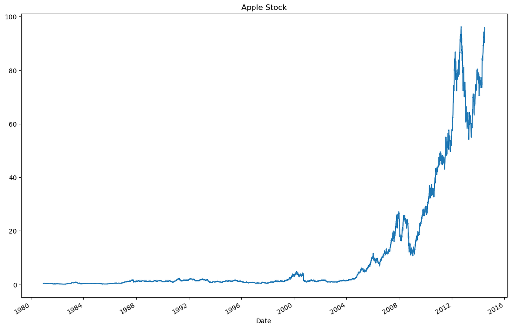

```python
appl_open = apple['Adj Close'].plot(title = "Apple Stock")

fig = appl_open.get_figure()
fig.set_size_inches(13.5, 9)
```

# Investor - Flow of Funds - US

# Introduction:

# Special thanks to: https://github.com/rgrp for sharing the dataset

# Step 1. Import the necessary libraries

```python
import pandas as pd
```